# A comparison of autocorrelations between pA-DamID and DamID

Tom van Schaik

2020-05-26

### Introduction

One reviewer commented that it would be useful to know and validate the resolution of pA-DamID. Real estimates of data resolution are difficult from our data, given the biological nature of the data. This really requires artificial experimental systems such as lacO integrations, where you know the protein binding sites and can estimate the reach of the method. Alternatively, you might be able to do this from transcription factor binding sites. However, we don’t have either of these.

Instead, we will “evade” the question with a comparison between pA-DamID and DamID. Given the size of LADs, you expect high autocorrelations in NL binding data. By calculating and comparing the autocorrelation for DamID and pA-DamID data (for a given total read count), we can make estimations of the maximum resolution that you can get.

Let’s see whether this idea actually works.

### Method

Calculate autocorrelation function of downscaled DamID and pA-DamID data.

### Set-up

Load the libraries and set the parameters.

```r
# Load dependencies
library(tidyverse)
library(yaml)
library(GenomicRanges)
library(rtracklayer)

# # Prepare output
output.dir <- "ts200317_comparing_autocorrelations"
dir.create(output.dir, showWarnings = FALSE)
```

```r
library(knitr)
opts_chunk$set(fig.width = 10, fig.height = 4, dev=c('png', 'pdf'),
               fig.path = file.path(output.dir, "figures/"))
pdf.options(useDingbats = FALSE)
```

```r
PrepareMetadata <- function(input.dir, config.file, class,
                            sample.parts = c("cell", "target"),
                            additional.filter = NULL) {

  # Get the data from the config file
  config <- read_yaml(config.file)
  config.dam_controls <- config$dam_controls
  config.replicates <- config$replicates

  tib <- tibble(sample = unlist(config.replicates),
                replicate = rep(names(config.replicates),
                                times = sapply(config.replicates, length)),
                class = class) %>%
    separate(replicate, sample.parts, remove = F) %>%
    filter(cell %in% cells,
           target %in% targets) %>%
    mutate(dam = unlist(config.dam_controls[sample])) %>%
    mutate(sample.file = file.path(input.dir, paste0(sample, "-gatc.counts.txt.gz")),
           dam.file = file.path(input.dir, paste0(dam, "-gatc.counts.txt.gz"))) %>%
    dplyr::select(sample, dam, replicate, class, cell, target, sample.file, dam.file)

  if (! is.null(additional.filter)) {
    tib <- tib %>%
      filter(grepl(additional.filter, sample))
  }

  tib
}

ReadCounts <- function(i, dam = F) {

  f <- ifelse(dam == F,
              metadata$sample.file[i],
              metadata$dam.file[i])
  s <- metadata$sample[i]

  read_tsv(f,
           col_names = c("seqnames",
                         "start",
                         "end",
                         "count"),
           col_types = cols_only(
             count = col_double()
           ),
           progress = FALSE) %>%
    rename_at(vars(names(.)), ~s)
}

DownSampling <- function(i, tib, sampling) {
  # A function to downsample the data, using random sampling without replacement.
  # While this function might be a bit slow, it is completely random sampling.

  # Get data
  x <- tib %>% pull(i)
  s <- metadata.downsample$sample[i]

  # Downsampling
  names(x) <- 1:length(x)

  y <- sample(rep(names(x), x),
              size=sampling, replace=FALSE)
  y <- table(factor(y, levels=names(x)))

  # Prepare output tibble with names
  tibble(count = as.vector(y)) %>%
    rename_at(vars(names(.)), ~ s)

}

NormReads <- function(tib, n = 1e6) {
  # Normalize for library size (in reads / M)
  tmp <- data.frame(t(t(tib) / colSums(tib)) * n)
  tmp <- as_tibble(tmp) %>%
    rename_at(vars(names(.)), ~ names(tib))
  tmp
}

CreateBins <- function(gatc.fragments, bin, chromosomes = NULL) {
    # Create bins of width "bin", using a genome size table (file)

    # First, read the genome size and select chromosomes
    g <- tibble(seqnames = seqlevels(gatc.fragments),
                seqlengths = seqlengths(gatc.fragments))

    if (! is.null(chromosomes)) {
      g <- g %>% filter(seqnames %in% chromosomes)
    }

    # For each chromosome, create bins
    start <- unlist(sapply(g$seqnames,
                           function(x) seq(from=1, by=bin,
                                           to=g$seqlengths[g$seqnames == x])))

    end <- unlist(sapply(g$seqnames, function(x) {
      s <- seq(from=bin,
               by=bin,
               to=ceiling(g$seqlengths[g$seqnames == x]/bin)*bin)
      s[length(s)] <- g$seqlengths[g$seqnames == x]
      s
    }))

    # Assert that everything is okay
    if (length(start) != length(end)) {
        stop("Oops, something went wrong with the binning")
    }

    # Create GRanges
    bins <- GRanges(seqnames = rep(g$seqnames, ceiling(g$seqlengths / bin)),
                    ranges = IRanges(start, end))
    seqlevels(bins) <- seqlevels(gatc.fragments)
    seqinfo(bins) <- seqinfo(gatc.fragments)
    bins <- sort(bins)
    bins
}

CountInBins <- function(bins, gr, counts) {
  # Collapse fragment counts into bins. For this, use the middle of the bin

  mid <- start(gr) + floor((end(gr)-start(gr))/2)
  mid <- GRanges(seqnames(gr),
                 IRanges(mid, mid))

  ovl <- findOverlaps(mid, bins, type='within')
  # stopifnot(all.equal(seq_along(gff.middle), queryHits(ovl)))
  if (all.equal(seq_along(mid), queryHits(ovl)) != TRUE) {
    cat("Note: not all fragments counted into bins!\n")
  }

  # Note: put the unique subjectHits in order (chromosome order)
  mcols(bins)[, names(counts)] <- 0
  mcols(bins)[sort(unique(subjectHits(ovl))), ] <-
    do.call(rbind,
            tapply(
              queryHits(ovl),
              subjectHits(ovl),
              function(x) colSums(counts[x, ])))

  bins

}

NormDam <- function(gr, c.lam, c.dam, pseudo = 1, min.reads = 0) {

  idx.low_reads <- c.lam + c.dam < min.reads

  # Add pseudocount for later divisions
  c.lam.df <- c.lam + pseudo
  c.dam.df <- c.dam + pseudo

  # Create normalized table
  norm <- log2(c.lam.df / c.dam.df)

  # Few reads == NA
  norm[idx.low_reads] <- NA

  norm <- as_tibble(norm) %>%
    rename_at(vars(names(.)), ~ names(mcols(gr)))
  mcols(gr) <- norm

  gr

}

CalculateACF <- function(bins.norm, bin) {

  acf.values <- sapply(1:ncol(mcols(bins.norm)),
                       function(i) {
                         acf(mcols(bins.norm)[, i],
                             lag.max = 2, na.action = na.pass,
                             plot = F)$acf[2]
                       })

  acf.tib <- tibble(sample = names(mcols(bins.norm)),
                    acf = acf.values,
                    bin = bin)
  acf.tib

}
```

### 1. List and load samples

I need to do this for pA-DamID and DamID data.

First, let’s list the cells and antibodies that I will look at.

```r
# List input targets
cells <- c("Hap1", "K562", "HCT116", "RPE")
targets <- c("LMNB1", "LMNB2", "LMNAC")
```

Prepare the metadata.

```r
# Read all required metadata
metadata.padamid <- PrepareMetadata(input.dir = "results/counts/bin-gatc/",
                                    config.file = "bin/snakemake/config.yaml",
                                    class = "pADamID")
metadata.padamid.rpe <- PrepareMetadata(input.dir = "../ts190509_RPE_HCT116_synchronization/results/counts/bin-gatc/",
                                        config.file = "../ts190509_RPE_HCT116_synchronization/bin/snakemake/config.yaml",
                                        class = "pADamID",
                                        sample.parts = c("f1", "cell", "f2", "target"),
                                        additional.filter = "bulk")
metadata.damid <- PrepareMetadata(input.dir = "/DATA/usr/t.v.schaik/proj/3D_nucleus/results/ts180110_4DN_DataProcessing/results/counts/bin-gatc/",
                                  config.file = "/DATA/usr/t.v.schaik/proj/3D_nucleus/results/ts180110_4DN_DataProcessing/bin/snakemake/config.yaml",
                                  class = "DamID")

# Combine metadata
metadata <- bind_rows(metadata.padamid,
                      metadata.padamid.rpe,
                      metadata.damid)

metadata %>%
  tbl_df %>%
  print(n = 100)
```

```
## # A tibble: 36 x 8
##    sample   dam     replicate class cell  target sample.file    dam.file
##    <chr>    <chr>   <chr>     <chr> <chr> <chr>  <chr>          <chr>
##  1 pADamID… pADamI… Hap1_LMN… pADa… Hap1  LMNB1  results/count… results/co…
##  2 pADamID… pADamI… Hap1_LMN… pADa… Hap1  LMNB1  results/count… results/co…
##  3 pADamID… pADamI… Hap1_LMN… pADa… Hap1  LMNB1  results/count… results/co…
##  4 pADamID… pADamI… Hap1_LMN… pADa… Hap1  LMNB2  results/count… results/co…
##  5 pADamID… pADamI… Hap1_LMN… pADa… Hap1  LMNB2  results/count… results/co…
##  6 pADamID… pADamI… Hap1_LMN… pADa… Hap1  LMNB2  results/count… results/co…
##  7 pADamID… pADamI… Hap1_LMN… pADa… Hap1  LMNB2  results/count… results/co…
##  8 pADamID… pADamI… Hap1_LMN… pADa… Hap1  LMNB2  results/count… results/co…
##  9 pADamID… pADamI… K562_LMN… pADa… K562  LMNB1  results/count… results/co…
## 10 pADamID… pADamI… K562_LMN… pADa… K562  LMNB1  results/count… results/co…
## 11 pADamID… pADamI… K562_LMN… pADa… K562  LMNB2  results/count… results/co…
## 12 pADamID… pADamI… K562_LMN… pADa… K562  LMNB2  results/count… results/co…
```

[output cut: 24 more lines]

Read the counts.

```r
# Read data
gatc.fragments <- read_tsv(metadata$sample.file[1],
                           col_names = c("seqnames", "start", "end", "count"),
                           col_types = cols_only(seqnames = col_character(),
                                                 start = col_double(),
                                                 end = col_double())) %>%
  as("GRanges")
start(gatc.fragments) <- start(gatc.fragments) + 1

# Add chrom sizes
chrom.sizes <- read.table("/DATA/usr/t.v.schaik/data/genomes/GRCh38/hg38.chrom.sizes",
                          sep = "\t")
row.names(chrom.sizes) <- chrom.sizes[, 1]

seqlengths(gatc.fragments) <- chrom.sizes[seqlevels(gatc.fragments), 2]

# Read counts
counts.lam <- do.call(bind_cols,
                      lapply(1:nrow(metadata), ReadCounts))

counts.dam <- do.call(bind_cols,
                      lapply(1:nrow(metadata), ReadCounts, dam = T))
```

Finally, save the counts as .rds files.

```r
# Save rds files
fragments.rds <- file.path(output.dir, "fragments.rds")
saveRDS(gatc.fragments, fragments.rds)

counts.lam.rds <- file.path(output.dir, "counts_lam.rds")
saveRDS(counts.lam, counts.lam.rds)

counts.dam.rds <- file.path(output.dir, "counts_dam.rds")
saveRDS(counts.dam, counts.dam.rds)
```

At this point, I have all GATC counts for all relevant experiment. With this, I can start with the real analysis. Note that all previous chuncks are cached, that should prevent too long loading times when preparing output documents.

### 2. Filter and downsample samples

I want to use a given number of reads for downsampling, let’s say 5M target and 5M Dam reads. This should allow for honest comparisons. This means that I have to filter and downsample samples. Again, let’s cache and save intermediate results as downsampling is intense.

```r
# Find samples with too few reads
reads.cutoff <- 5e6

idx.lam <- colSums(counts.lam) > reads.cutoff
idx.dam <- colSums(counts.dam) > reads.cutoff
idx <- idx.lam & idx.dam

metadata.downsample <- metadata[idx, ]
counts.lam.downsample <- counts.lam[, idx]
counts.dam.downsample <- counts.dam[, idx]
```

Downsampling.

```r
# Downsampling to #reads.cutoff reads
set.seed(123)

counts.lam.downsample <- do.call(bind_cols,
                                 lapply(1:nrow(metadata.downsample),
                                        DownSampling,
                                        tib = counts.lam.downsample,
                                        sampling = reads.cutoff))

counts.dam.downsample <- do.call(bind_cols,
                                 lapply(1:nrow(metadata.downsample),
                                        DownSampling,
                                        tib = counts.dam.downsample,
                                        sampling = reads.cutoff))

# Normalize to 1M reads
counts.lam.downsample <- NormReads(counts.lam.downsample)
counts.dam.downsample <- NormReads(counts.dam.downsample)

# Save downsampled
counts.lam.downsample.rds <- file.path(output.dir, "counts_lam_downsample.rds")
saveRDS(counts.lam.downsample, counts.lam.downsample.rds)

counts.dam.downsample.rds <- file.path(output.dir, "counts_dam_downsample.rds")
saveRDS(counts.dam.downsample, counts.dam.downsample.rds)
```

### 3. Calculate ACF in different bin sizes

Next, I will count the data in different bin sizes and normalize the data over Dam.

```r
# Loop over bin sizes, every time normalizing and calculate acf value
bin.sizes <- c(1e3, 2e3, 5e3,
               1e4, 2e4, 5e4,
               1e5, 2e5, 5e5,
               1e6)
chromosomes <- c("chr1")
#bin.sizes <- c(1e5, 2e5, 5e5, 1e6)

tib.acf <- tibble()
bins.lam.list <- list()
bins.dam.list <- list()

for (bin in bin.sizes) {

  cat("Processing bin size:", bin, "bps\n")

  bins <- CreateBins(gatc.fragments, bin = bin, chromosomes = chromosomes)

  # Use the biggest bin size possible
  bins.before <- bin %/% bin.sizes > 1 & bin %% bin.sizes == 0

  if (any(bins.before)) {
    bin.previous <- as.character(tail(bin.sizes[bins.before], n = 1))
    cat("   Using previous bin size:", bin.previous, "bps\n")

    bins.lam <- CountInBins(bins, bins.lam.list[[bin.previous]],
                            as_tibble(mcols(bins.lam.list[[bin.previous]])) %>%
                              rename_at(vars(names(.)), ~ metadata.downsample$sample))
    bins.dam <- CountInBins(bins, bins.dam.list[[bin.previous]],
                            as_tibble(mcols(bins.dam.list[[bin.previous]])) %>%
                              rename_at(vars(names(.)), ~ metadata.downsample$sample))
  } else {
    cat("   Using GATC fragments\n")

    bins.dam <- CountInBins(bins, gatc.fragments, counts.dam.downsample)
    bins.lam <- CountInBins(bins, gatc.fragments, counts.lam.downsample)
  }

  bins.lam.list[[as.character(bin)]] <- bins.lam
  bins.dam.list[[as.character(bin)]] <- bins.dam

  bins.norm <- NormDam(bins.lam,
                       as_tibble(mcols(bins.lam)),
                       as_tibble(mcols(bins.dam)))

  bins.acf <- CalculateACF(bins.norm, bin = bin)
  tib.acf <- bind_rows(tib.acf, bins.acf)
}
```

```
## Processing bin size: 1000 bps
##    Using GATC fragments
## Note: not all fragments counted into bins!
## Note: not all fragments counted into bins!
## Processing bin size: 2000 bps
##    Using previous bin size: 1000 bps
## Processing bin size: 5000 bps
##    Using previous bin size: 1000 bps
## Processing bin size: 10000 bps
##    Using previous bin size: 5000 bps
## Processing bin size: 20000 bps
##    Using previous bin size: 10000 bps
## Processing bin size: 50000 bps
##    Using previous bin size: 10000 bps
## Processing bin size: 1e+05 bps
##    Using previous bin size: 50000 bps
## Processing bin size: 2e+05 bps
##    Using previous bin size: 1e+05 bps
## Processing bin size: 5e+05 bps
##    Using previous bin size: 1e+05 bps
## Processing bin size: 1e+06 bps
##    Using previous bin size: 5e+05 bps
```

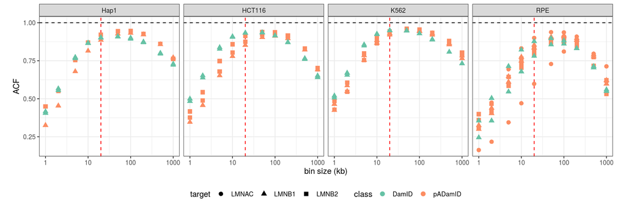

```r
# Process acf tibble
idx <- match(tib.acf$sample, metadata$sample)

tib.acf <- tib.acf %>%
  mutate(class = metadata$class[idx],
         cell = metadata$cell[idx],
         target = metadata$target[idx])

# Save rds values
saveRDS(tib.acf, file.path(output.dir, "tib_ACF.rds"))
saveRDS(bins.lam.list, file.path(output.dir, "bins_lam_list.rds"))
saveRDS(bins.dam.list, file.path(output.dir, "bins_dam_list.rds"))

# Plot
tib.acf %>%
  ggplot(aes(x = bin / 1e3, y = acf, col = class, shape = target)) +
    geom_hline(yintercept = 1, col = "black", linetype = "dashed") +
    geom_vline(xintercept = 20, col = "red", linetype = "dashed") +
    geom_point(size = 2.5) +
    facet_grid(. ~ cell) +
    coord_cartesian(ylim = c(min(tib.acf$acf), 1)) +
    xlab("bin size (kb)") +
    ylab("ACF") +
    scale_x_log10() +
    scale_color_brewer(palette = "Set2") +
    theme_bw() +
    theme(aspect.ratio = 1,
          legend.position="bottom")
```

### 4. Downsampling versus ACF

To show that more reads result in a higher “useful resolution”, also do some downsampling. Use K562 r1 LMNB1, which has most reads I believe.

```r
# Prepare sample & parameters
metadata.downsample <- metadata

sample <- "K562_r1_LMNB1"
i <- which(names(counts.lam) == sample)

reads.counts <- c(1e7,
                  5e6, 2e6, 1e6,
                  5e5, 2e5, 1e5,
                  5e4)
chromosomes <- c("chr1")


# Downsamping
counts.lam.sample.downsample <- do.call(cbind,
                                        lapply(reads.counts,
                                               function(x) {
                                                 DownSampling(i, counts.lam, x)
                                               }))
counts.lam.sample.downsample <- as_tibble(counts.lam.sample.downsample,
                                          .name_repair = ~ as.character(reads.counts))
```

```
## * K562_r1_LMNB1 -> `1e+07`
## * K562_r1_LMNB1 -> `5e+06`
## * K562_r1_LMNB1 -> `2e+06`
## * K562_r1_LMNB1 -> `1e+06`
## * K562_r1_LMNB1 -> `5e+05`
## * ...
```

```r
counts.dam.sample.downsample <- do.call(cbind,
                                        lapply(reads.counts,
                                               function(x) {
                                                 DownSampling(i, counts.dam, x)
                                               }))
counts.dam.sample.downsample <- as_tibble(counts.dam.sample.downsample,
                                          .name_repair = ~ as.character(reads.counts))
```

```
## * K562_r1_LMNB1 -> `1e+07`
## * K562_r1_LMNB1 -> `5e+06`
## * K562_r1_LMNB1 -> `2e+06`
## * K562_r1_LMNB1 -> `1e+06`
## * K562_r1_LMNB1 -> `5e+05`
## * ...
```

```r
# Calculate ACF
tib.acf <- tibble()
bin.sizes <- c(1e3, 5e3, 1e4, 2e4)

for (bin in bin.sizes) {

  print(bin)

  # 1) Create bins
  bins <- CreateBins(gatc.fragments, bin = bin, chromosomes = chromosomes)
  # 2) Count in bins
  bins.dam <- CountInBins(bins, gatc.fragments, counts.dam.sample.downsample)
  bins.lam <- CountInBins(bins, gatc.fragments, counts.lam.sample.downsample)
  # 3) Normalize
  bins.norm <- NormDam(bins.lam,
                       as_tibble(mcols(bins.lam)),
                       as_tibble(mcols(bins.dam)))
  # 4) Calculate ACF
  bins.acf <- CalculateACF(bins.norm, bin = bin)
  tib.acf <- bind_rows(tib.acf, bins.acf)

}
```

```
## [1] 1000
## Note: not all fragments counted into bins!
## Note: not all fragments counted into bins!
## [1] 5000
## Note: not all fragments counted into bins!
## Note: not all fragments counted into bins!
## [1] 10000
## Note: not all fragments counted into bins!
## Note: not all fragments counted into bins!
## [1] 20000
## Note: not all fragments counted into bins!
## Note: not all fragments counted into bins!
```

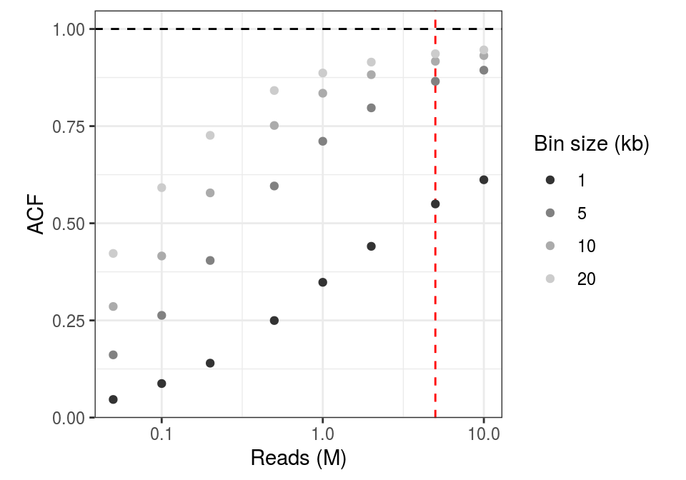

```r
# Plot the results
tib.acf <- tib.acf %>%
  mutate(downsample = as.numeric(sample),
         bin = factor(bin / 1e3))

# Plot
tib.acf %>%
  ggplot(aes(x = downsample / 1e6, y = acf, col = bin)) +
    geom_hline(yintercept = 1, col = "black", linetype = "dashed") +
    geom_vline(xintercept = 5, col = "red", linetype = "dashed") +
    #geom_vline(xintercept = nrow(counts.lam) / 1e6,
    #           col = "green", linetype = "dashed") +
    geom_point() +
    coord_cartesian(ylim = c(min(tib.acf$acf), 1)) +
    #facet_grid(. ~ bin / 1e3) +
    scale_color_grey(name = "Bin size (kb)") +
    xlab("Reads (M)") +
    ylab("ACF") +
    scale_x_log10() +
    theme_bw() +
    theme(aspect.ratio = 1)
```